# SVM

Manpreet S. Katari

4/27/2018

## SVM

SVM tries to create a hyperplane that spans across the all the dimensions. The model formula is written the same way as we have used in the past.

The **kernel** option tells the function the type of hyperplane you want to fit. It can be something simple as **linear** or more complex as **polynomial**

The **cost** option tells the function the penalty it should give for violoation ( a point present in the wrong side of the plane). So a high value will force a plane that is narrower and a low value will have a wider range.

The **probability** option is asking the resulting model to be used for providing probabilities.

### Load the data

```r
#install.packages("e1071")
library(e1071)

data = read.table("all.15k.patients.txt",
                  header=1)

data$alivestatus = as.factor(data$alivestatus)
```

### Separate training and test dataset

```r
sample(15000, 5000, replace=F)->data.test.index

data.test = data[data.test.index,]
data.train = data[-data.test.index,]
```

### Build the model

```r
data.svm = svm(alivestatus ~ grade + nodespos + nodesexam + size + pgr + er,
            data = data.train, kernel="linear", cost=10,
            probability=T)
```

The model uis using several variables, but we can only see a graph with a select few. Letâs see how the **nodespos** and **size** separate into live and dead patients.

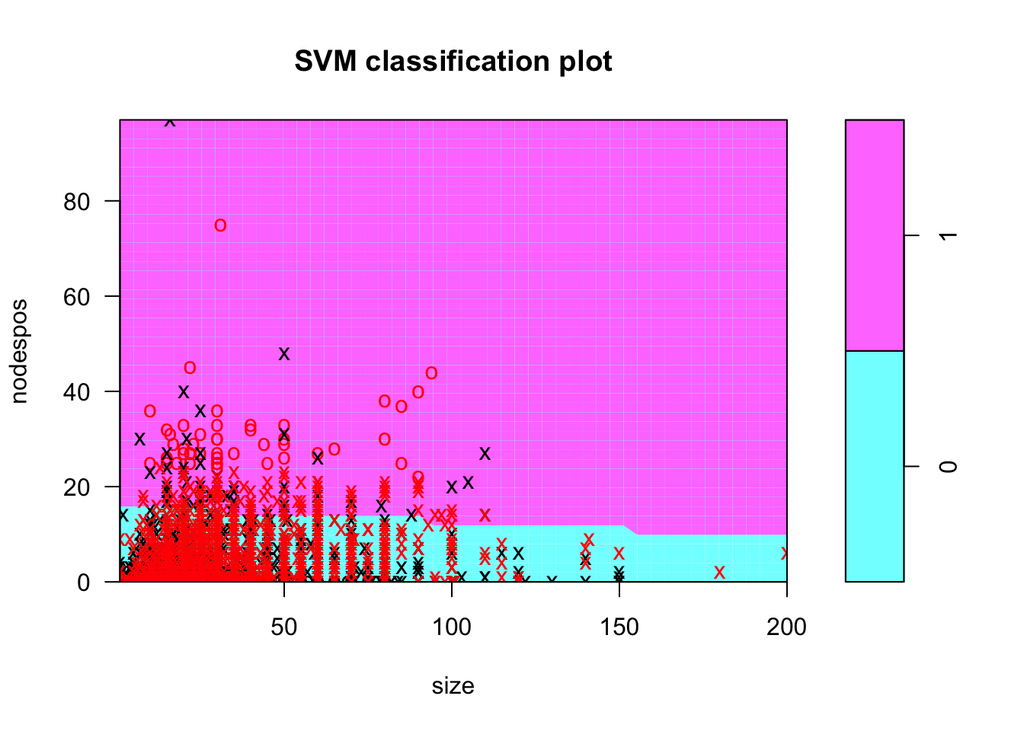

```r
plot(data.svm, data.train, nodespos ~ size)
```

### Testing the model

We can use the **predict** function ( just like we did for glm() function ) to determine results of the data provided. If we were using a test dataset, we can simply use the **newdata** option in predict.

```r
data.svm.pred.prob = predict(data.svm, data.test,
                             probability=T)
table(data.svm.pred.prob,data.test$alivestatus)
```

```
##
## data.svm.pred.prob    0    1
##                  0 3952  731
##                  1  120  197
```

The probabilities are stored as an attribute in the results. You can retrieve it using the **attr** function.

```r
data.svm.pred.prob.mat = attr(data.svm.pred.prob, "probabilities")
```

Now that we have the probabilities, we can calculte the AUC.

```r
library(AUC)
datasvmroc = roc(predictions = data.svm.pred.prob.mat[,2], data.test$alivestatus)
auc(datasvmroc)
```

```
## [1] 0.7810208
```

```r
data.svm = svm(alivestatus ~ grade + nodespos + nodesexam + size + pgr + er,
            data = data.train, kernel="radial", cost=1,
            probability=T)

data.svm.pred.prob = predict(data.svm, data.test,
                             probability=T)

data.svm.pred.prob.mat = attr(data.svm.pred.prob, "probabilities")
datasvmroc = roc(predictions = data.svm.pred.prob.mat[,2], data.test$alivestatus)
auc(datasvmroc)
```

```
## [1] 0.6981367
```

That made it worse. The goal is to change the parameters ( cost and kernel ) to see which will give you the best predictive model.